Link to this document's Jupyter Notebook

In order to successfully complete this assignment you need to participate both individually and in groups during class. If you attend class in-person then have one of the instructors check your notebook and sign you out before leaving class. If you are attending asynchronously, turn in your assignment using D2L no later than *11:59pm on the day of class*. See links at the end of this document for access to the class timeline for your section.

In order to successfully complete this assignment you need to participate both individually and in groups during class. If you attend class in-person then have one of the instructors check your notebook and sign you out before leaving class. If you are attending asyncronously, turn in your assignment using D2L no later than *11:59pm on the day of class*. See links at the end of this document for access to the class timeline for your section.

# In-Class Assignment: Diagonalization

[figure not shown]

Image from: https://en.wikipedia.org/wiki/Diagonalizable_matrix

### Agenda for today's class (80 minutes)

1. (20 minutes) Quiz 3 Review
2. (20 minutes) Pre-class Assignment Review
3. (20 minutes) Diagonalization
4. (20 minutes) The Power of a Matrix

```python
%matplotlib inline
import matplotlib.pylab as plt
import numpy as np
import sympy as sym
sym.init_printing()
```

# 1. Quiz 3 Review

Time is set aside to ask questions about homework.

# 2. Pre-class Assignment Review

- 15--Diagonalization_pre-class-assignment.ipynb

# 3. Diagonalization

*Reminder*: The eigenvalues of triangular (upper and lower) and diagonal matrices are easy:

- The eigenvalues for triangular matrices are the diagonal elements.
- The eigenvalues for the diagonal matrices are the diagonal elements.

## Diagonalization

**Definition**: A square matrix $A$ is said to be *diagonalizable* if there exist a matrix $C$ such that $D=C^{-1}AC$ is a diagonal matrix.

**Definition**: $B$ is a *similar matrix* of $A$ if we can find $C$ such that $B=C^{-1}AC$.

Given an $n\times n$ matrix $A$, can we find another $n \times n$ invertable matrix $C$ such that when $D=C^{-1}AC$ is diagonal, i.e., $A$ is diagonalizable?

- Because $C$ is inveritble, we have $$C^{-1}AC=D \\ CC^{-1}AC = CD\\ AC = CD $$
- Generate $C$ as the columns of $n$ linearly independent vectors $(x_1...x_n)$ We can compute $AC=CD$ as follows: $$ A\begin{bmatrix} \vdots & \vdots & \vdots & \vdots \\ \vdots & \vdots & \vdots & \vdots \\ { x }_{ 1 } & { x }_{ 2 } & \dots & { x }_{ n } \\ \vdots & \vdots & \vdots & \vdots \end{bmatrix}=AC=CD=\begin{bmatrix} \vdots & \vdots & \vdots & \vdots \\ \vdots & \vdots & \vdots & \vdots \\ { x }_{ 1 } & { x }_{ 2 } & \dots & { x }_{ n } \\ \vdots & \vdots & \vdots & \vdots \end{bmatrix}\begin{bmatrix} { \lambda }_{ 1 } & 0 & 0 & 0 \\ 0 & { \lambda }_{ 2 } & 0 & 0 \\ \vdots & \vdots & { \dots } & \vdots \\ 0 & 0 & 0 & { \lambda }_{ n } \end{bmatrix}$$
- Then we check the corresponding columns of the both sides. We have $$Ax_1 = \lambda_1x_1\\\vdots\\Ax_n=\lambda x_n$$
- $A$ has $n$ linear independent eigenvectors.
- $A$ is saied to be *similar* to the diagonal matrix $D$, and the transformation of $A$ into $D$ is called a *similarity transformation*.

### A simple example

Consider the following: $$ A = \begin{bmatrix}7& -10\\3& -4\end{bmatrix},\quad C = \begin{bmatrix}2& 5\\1& 3\end{bmatrix}$$

✅ **Do this:** Find the similar matrix $D = C^{-1}AC$ of $A$.

```python
#Put your answer to the above question here.
```

```python
from answercheck import checkanswer

checkanswer.matrix(D, '8313fe0f529090d6a8cdb36248cfdd6c');
```

✅ **Do this:** Find the eigenvalues and eigenvectors of $A$. Set variables `e1` and `vec1` to be the smallest eigenvalue and it's associated eigenvector and `e2, vec2` to represent the largest.

```python
#Put your answer to the above question here.
```

```python
from answercheck import checkanswer
checkanswer.float(e1, "e4c2e8edac362acab7123654b9e73432");
```

```python
from answercheck import checkanswer
checkanswer.float(e2, "d1bd83a33f1a841ab7fda32449746cc4");
```

```python
from answercheck import checkanswer
checkanswer.eq_vector(vec1, "d28f0a721eedb3d5a4c714744883932e", decimal_accuracy = 4)
```

```python
from answercheck import checkanswer
checkanswer.eq_vector(vec2, "09d9df5806bc8ef975074779da1f1023", decimal_accuracy = 4)
```

**Theorem:** Similar matrices have the same eigenvalues.

**Proof:** Assume $B=C^{-1}AC$ is a similar matrix of $A$, and $\lambda$ is an eigenvalue of $A$ with corresponding eigenvector $x$. That is, $$Ax=\lambda x$$ Then we have $$B(C^{-1}x) = C^{-1}AC(C^{-1}x) = C^{-1}Ax = C^{-1}(\lambda x)= \lambda (C^{-1}x).$$ That is $C^{-1}x$ is an eigenvector of $B$ with eigenvalue $\lambda$.

### A second example

✅ **Do this:** Consider $$ A = \begin{bmatrix}-4& -6\\3& 5\end{bmatrix}.$$ Find a matrix $C$ such that $C^{-1}AC$ is diagonal. (Hint, use the function `diagonalize` in `sympy`.)

```python
#Put your answer to the above question here.
```

```python
#Check the output type
assert(type(C)==sym.Matrix)
```

```python
from answercheck import checkanswer
checkanswer.matrix(C,'ba963b7fef354b4a7ddd880ca4bac071')
```

### The third example

✅ **Do this:** Consider $$ A = \begin{bmatrix}5& -3\\3& -1\end{bmatrix}.$$ Can we find a matrix $C$ such that $C^{-1}AC$ is diagonal? (Hint: find eigenvalues and eigenvectors using `sympy`)

```python
#Put your answer to the above question here.
```

## Dimensions of eigenspaces and diagonalization

**Definition**: The set of all eigenvectors of a $n\times n$ matrix corresponding to a eigenvalue $\lambda$, together with the zero vector, is a subspace of $R^n$. This subspace spaces is called *eigenspace*.

- For the third example, we have that the characteristic equation $(\lambda-2)^2=0$.
- Eigenvalue $\lambda=2$ has multiplicity 2, but the eigenspace has dimension 1, since we can not find two lineare independent eigenvector for $\lambda =2$.

> The dimension of an eigenspace of a matrix is less than or equal to the multiplicity of the corresponding eigenvalue as a root of the characteristic equation.

> A matrix is diagonalizable if and only if the dimension of every eigenspace is equal to the multiplicity of the corresponding eigenvalue as a root of the characteristic equation.

### The fourth example

✅ **Do this:** Consider $$ A = \begin{bmatrix}2& -1\\1& 2\end{bmatrix}.$$ Can we find a matrix $C$ such that $C^{-1}AC$ is diagonal?

```python
#Put your answer to the above question here.
```

# 4. The Power of a Matrix

- For a diagonalizable matrix $A$, we have $C^{-1}AC=D$. Then we have $$A = C D C^{-1}$$
- We have $$A^2 = C D C^{-1} C D C^{-1} = C D^2 C^{-1}$$ $$A^n = C D C^{-1} \dots C D C^{-1} = C D^n C^{-1}$$
- Because the columns of $C$ are eigenvectors, so we can say that the eigenvectors for $A$ and $A^n$ are the same if $A$ is diagonalizable.
- If $x$ is an eigenvector of $A$ with the corresponding eigenvalue $\lambda$, then $x$ is also an eigenvector of $A^n$ with the corresponding eigenvalue $\lambda^n$.

```python
# Here are some libraries you may need to use
%matplotlib inline
import numpy as np
import sympy as sym
import networkx as nx
import matplotlib.pyplot as plt
sym.init_printing(use_unicode=True)
```

### Graph Random Walk

- Define the following matrices:
  - $I$ is the identity matrix
  - $A$ is the adjacency matrix
  - $D$ is diagonal matrix of degrees (number of edges connected to each node)

$$W=\frac{1}{2}(I + AD^{-1})$$

- The **lazy random walk matrix**, $W$, takes a distribution vector of *stuff*, $p_{t}$, and diffuses it to its neighbors:

$$p_{t+1}=Wp_{t}$$

- For some initial distribution of *stuff*, $p_{0}$, we can compute how much of it would be at each node at time, $t$, by powering $W$ as follows:

$$p_{t}=W^{t}p_{0}$$

- Plugging in the above expression yields:

$$p_{t}=\left( \frac{1}{2}(I+AD^{-1}) \right)^t p_{0}$$

**DO THIS**: Using matrix algebra, show that $\frac{1}{2}(I + AD^{-1})$ is **similar** to $I-\frac{1}{2}N$, where $N=D^{-\frac{1}{2}}(D-A)D^{-\frac{1}{2}}$ is the normalized graph Laplacian.

**Your answer goes here** (follow along after attempting)

### Random Walk on Barbell Graph

To generate the barbell graph, run the following cell.

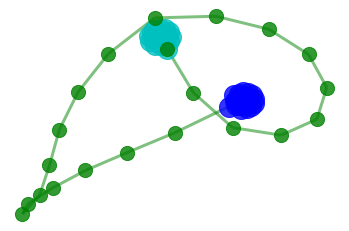

```python
n = 60 # number of nodes
B = nx.Graph() # initialize graph

## initialize empty edge lists
edge_list_complete_1 = []
edge_list_complete_2 = []
edge_list_path = []

## generate node lists
node_list_complete_1 = np.arange(int(n/3))
node_list_complete_2 = np.arange(int(2*n/3),n)
node_list_path = np.arange(int(n/3)-1,int(2*n/3))

## generate edge sets for barbell graph
for u in node_list_complete_1:
    for v in np.arange(u+1,int(n/3)):
        edge_list_complete_1.append((u,v))

for u in node_list_complete_2:
    for v in np.arange(u+1,n):
        edge_list_complete_2.append((u,v))

for u in node_list_path:
    edge_list_path.append((u,u+1))

# G.remove_edges_from([(3,0),(5,7),(0,7),(3,5)])

## add edges
B.add_edges_from(edge_list_complete_1)
B.add_edges_from(edge_list_complete_2)
B.add_edges_from(edge_list_path)


## draw graph
pos=nx.spring_layout(B) # positions for all nodes

### nodes
nx.draw_networkx_nodes(B,pos,
                       nodelist=list(node_list_complete_1),
                       node_color='c',
                       node_size=400,
                       alpha=0.8)
nx.draw_networkx_nodes(B,pos,
                       nodelist=list(node_list_path),
                       node_color='g',
                       node_size=200,
                       alpha=0.8)
nx.draw_networkx_nodes(B,pos,
                       nodelist=list(node_list_complete_2),
                       node_color='b',
                       node_size=400,
                       alpha=0.8)


### edges
nx.draw_networkx_edges(B,pos,
                       edgelist=edge_list_complete_1,
                       width=2,alpha=0.5,edge_color='c')
nx.draw_networkx_edges(B,pos,
                       edgelist=edge_list_path,
                       width=3,alpha=0.5,edge_color='g')
nx.draw_networkx_edges(B,pos,
                       edgelist=edge_list_complete_2,
                       width=2,alpha=0.5,edge_color='b')


plt.axis('off')
plt.show() # display
```

✅ **Do this:** Generate the lazy random walk matrix, $W$, for the above graph.

```python
A = nx.adjacency_matrix(B)
A = A.todense()

d = np.sum(A,0) # Make a vector of the sums.
D = np.diag(np.asarray(d)[0])
```

```python
#Put your answer to the above question here.
```

```python
from answercheck import checkanswer
checkanswer.matrix(W, "7af4a5b11892da6e1a605c8239b62093")
```

✅ **Do this:** Compute the eigenvalues and eigenvectors of $W$. Make a diagonal matrix $J$ with the eigenvalues on the diagonal. Name the matrix of eigenvectors $V$ (each column is an eigenvector).

```python
#Put your answer to the above question here.
```

Now we make sure we constructed $V$ and $A$ correctly by double checking that $W = VJV^{-1}$

```python
np.allclose(W, V*J*np.linalg.inv(V))
```

✅ **Do this:** Let your $p_{0}=[1,0,0,\ldots,0]$. Compute $p_{t}$ for $t=1,2,\ldots,100$, and plot $||v_{1}-p_{t}||_{1}$ versus $t$, where $v_{1}$ is the eigenvector associated with the largest eigenvalue $\lambda_{1}=1$ and whose sum equals 1. (**Note**: $||\cdot||_{1}$ may be computed using `np.linalg.norm(v_1-p_t, 1)`.)

```python
#Put your answer to the above question here.
```

#### Compare to Complete Graph

If you complete the above, do the same for a complete graph on the same number of nodes.

✅ **Question:** What do you notice about the graph that is different from that above?

Put your answer to the above question here.

### Congratulations, we're done!

If you attend class in-person then have one of the instructors check your notebook and sign you out before leaving class. If you are attending asynchronously, turn in your assignment using D2L.

### Course Resources:

- [MTH314 Course Website](http://cmse.msu.edu/mth314)

Written by Dr. Dirk Colbry, Michigan State University  
This work is licensed under a [Creative Commons Attribution-NonCommercial 4.0 International License](http://creativecommons.org/licenses/by-nc/4.0/).